# EP06

Bastian Brito, Sebastian Cassone

2024-04-22

# Enunciado

Un equipo de investigadores del área de interacción humano-información está estudiando si el área temática y el nivel de dificultad del problema de información influyen en el tiempo (en segundos) que toma un usuario en formular una consulta de búsqueda para resolver dicho problema. Para ello, han reclutado a un grupo de participantes voluntarios, asignados aleatoriamente a distintos grupos. Cada participante debe resolver tres problemas de información con diferentes niveles de dificultad: baja, media y alta. A su vez, cada grupo debe resolver problemas relacionados a una temática diferente. Los datos recolectados contemplan las siguientes variables:

id: identificador único de cada participante. area: Área temática de los problemas que el participante debe responder. Variable categórica con los niveles Arquitectura, Biología, Computación, Economía, Física, Leyes, Literatura, Matemáticas, Música, Pedagogía, Psicología, Química. dificultad: Nivel de dificultad del problema resuelto. Variable categórica con los niveles Baja, Media y Alta. tiempo: Tiempo, en segundos, que toma al participante formular la consulta.

# Pregunta

En este momento, los investigadores buscan determinar si existen diferencias en el tiempo que tardan los usuarios en formular consultas para problemas con diferente nivel de dificultad en el área de leyes.

Primero, se lee el archivo csv.

```r
# Importamos las librerías
library(dplyr)
library(ggpubr)
library(ez)
library(emmeans)
library(nlme)
# Lectura de archivo
# Se abre el CSV, cambiar la ruta según corresponda
nombre_archivo <- "EP06 Datos.csv"
carpeta_direccion <- "~/Documentos/ejercicios_R/EI/estadistica_inferencial_grupo6/EP06"
ruta <- file.path(carpeta_direccion, nombre_archivo)
datos <- read.csv(ruta, stringsAsFactors = TRUE)
# Filtrar por tipo de cubo y países
datos_filtrados <- datos %>%
  filter(area == "Leyes")
datos_filtrados
```

```
##       id  area dificultad tiempo
## 1      1 Leyes       Baja     75
## 2      1 Leyes      Media     95
## 3      1 Leyes       Alta     96
## 4     19 Leyes       Baja     80
## 5     19 Leyes      Media     92
## 6     19 Leyes       Alta     72
## 7     54 Leyes       Baja     83
## 8     54 Leyes      Media     88
## 9     54 Leyes       Alta    102
## 10    66 Leyes       Baja     77
## 11    66 Leyes      Media     75
## 12    66 Leyes       Alta     84
## 13    77 Leyes       Baja     88
## 14    77 Leyes      Media     89
```

[output cut: 586 more lines]

En este momento, los investigadores buscan determinar si existen diferencias en el tiempo que tardan los usuarios en formular consultas para problemas con diferente nivel de dificultad en el área de leyes.

H0: No existen diferencias en la media del tiempo que tardan en formular consultas las mismas personas para problemas con diferente nivel de dificultad en el área de leyes. Ha: Existe al menos una diferencia en las medias con respecto al tiempo que tardan en formular consultas las mismas personas para problemas con diferente nivel de dificultad en el área de leyes.

Para usar Anova se tienen que cumplir estas 4 condiciones:

1.- La escala con que se midede la variable dependiente tiene las propiedades de una escala de intervalos iguales

Se cumple que los intervalos de la variable dependiente (tiempo) posee propiedades de una escala de intervalos iguales(La diferencia entre 10 y 20 seg, es la misma entre 20 y 30 seg)

2.- Las mediciones son independientes al interior de cada grupo

El enunciado señala que el proceso de selección de las personas garantiza el cumplimiento, ya que reclutaron voluntarios asignados aleatoriamente a distintos grupos

3.- Los datos siguen una distribucion parecida a la normal

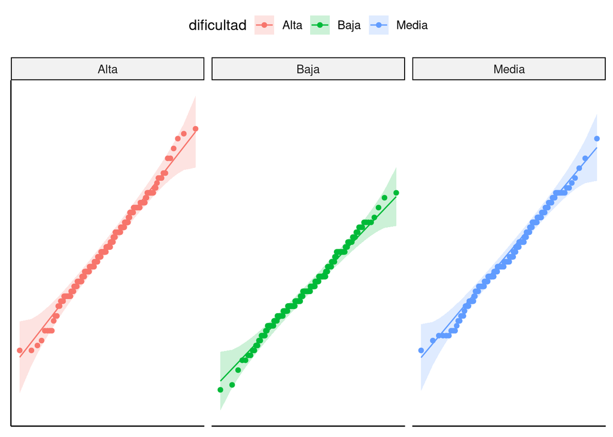

```r
# Comprobamos la normalidad de los datos con el gráfico q-q
g <- ggqqplot(datos_filtrados, x = "tiempo", y = "dificultad", color = "dificultad")
g <- g + facet_wrap(~dificultad)
g <- g + rremove("x.ticks") + rremove("x.text")
g <- g + rremove("y.ticks") + rremove("y.text")
g <- g + rremove("axis.title")
print(g)
```

```r
# Comprobamos la normalidad de los datos con el test de Shapiro
shapiro_alta <- shapiro.test((datos_filtrados %>% filter(dificultad == "Alta"))$tiempo)
shapiro_media <- shapiro.test((datos_filtrados %>% filter(dificultad == "Media"))$tiempo)
shapiro_baja <- shapiro.test((datos_filtrados %>% filter(dificultad == "Baja"))$tiempo)
shapiro_alta
```

```
##
##  Shapiro-Wilk normality test
##
## data:  (datos_filtrados %>% filter(dificultad == "Alta"))$tiempo
## W = 0.99291, p-value = 0.4488
```

```r
shapiro_media
```

```
##
##  Shapiro-Wilk normality test
##
## data:  (datos_filtrados %>% filter(dificultad == "Media"))$tiempo
## W = 0.9925, p-value = 0.3975
```

```r
shapiro_baja
```

```
##
##  Shapiro-Wilk normality test
##
## data:  (datos_filtrados %>% filter(dificultad == "Baja"))$tiempo
## W = 0.99205, p-value = 0.3476
```

Como se puede apreciar en el gráfico todas las muestras siguen razonablemente una distribución normal, por lo que se puede asumir razonablemente que la población de origen también sigue una distribución normal. Además se utiliza el test shapiro-wilk y se puede observa que son mayores a una significancia del 0.05 por lo que se acepta las hipótesis nulas de estos test que es que las muestras siguen una distribución normal.

4.- La matriz de varianzas-covarianzas es esférica. Esta condición se verificará una vez hecha la prueba de ANOVA con la prueba de esfericididad de Mauchly.

Una vez verificadas las tres condiciones (la cuarta se verificará una vez hecha la prueba) se hace la prueba de ANOVA para muestras correlacionadas.

```r
# Se hace la prueba de ANOVA para muestras correlacionadas.
prueba_anova <- ezANOVA(data = datos_filtrados, dv = tiempo, within = dificultad,
                          wid = id, return_aov = TRUE)
print(summary(prueba_anova$aov))
```

```
##
## Error: id
##            Df Sum Sq Mean Sq F value Pr(>F)
## Residuals 199  11759   59.09
##
## Error: id:dificultad
##             Df Sum Sq Mean Sq F value Pr(>F)
## dificultad   2   8179    4089   67.78 <2e-16 ***
## Residuals  398  24013      60
## ---
## Signif. codes:  0 '***' 0.001 '**' 0.01 '*' 0.05 '.' 0.1 ' ' 1
```

```r
print(prueba_anova$`Mauchly's Test for Sphericity`)
```

```
##       Effect         W         p p<.05
## 2 dificultad 0.9794031 0.1274044
```

Con respecto a la prueba de esfericididad de Mauchly se acepta la hipótesis nula de que la matriz de varianzas y covarianzas es esférica por lo que se cumple todas las condiciones de ANOVA de una vía para muestras correlacionadas. Con el p-value < 2e-16 y este a su vez es menor que la signficancia considerada para este experimiento del 0.05, rechazamos la hipótesis nula y aceptamos la hipótesis alternativa de que existe al menos una diferencia en las medias con respecto al tiempo que tardan en formular consultas las mismas personas para problemas con diferente nivel de dificultad en el área de leyes

Luego, hacemos un análsis post-hoc para determinar cuál o cuales son las dificultades que tienen una media de tiempo diferente, para esto utilizaremos el procedimiento HSD de Tukey.

```r
# Se hace la prueba post-hoc HSD de Tukey
mixto <- lme(tiempo ~ dificultad, data = datos_filtrados, random = ~1|id)
medias <- emmeans(mixto, "dificultad")
tukey <- pairs(medias, adjust = "tukey")
print(tukey)
```

```
##  contrast     estimate    SE  df t.ratio p.value
##  Alta - Baja      8.63 0.774 398  11.155  <.0001
##  Alta - Media     1.99 0.774 398   2.571  0.0283
##  Baja - Media    -6.64 0.774 398  -8.584  <.0001
##
## Degrees-of-freedom method: containment
## P value adjustment: tukey method for comparing a family of 3 estimates
```

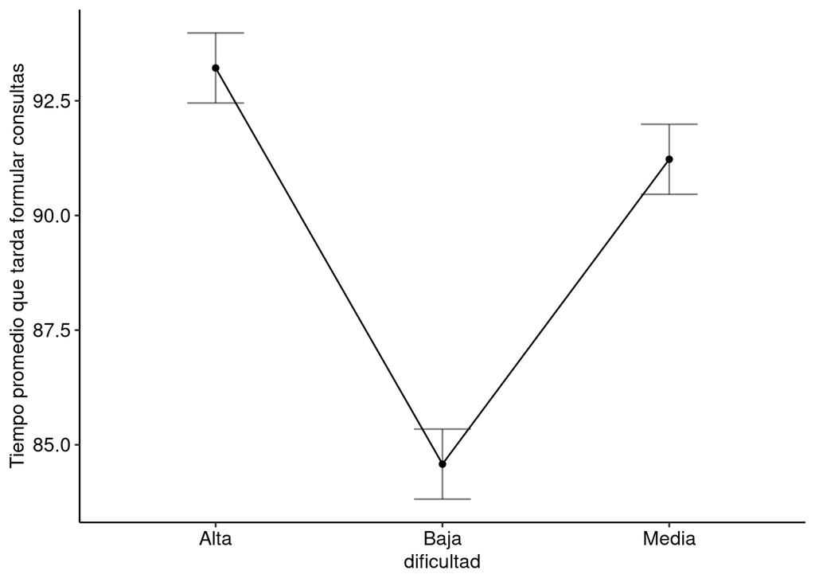

```r
# Se grafica el tamaño del efecto
tamaño_efecto <- ezPlot(data = datos_filtrados, dv = tiempo, wid = id, within = dificultad, y_lab= "Tiempo promedio que tarda formular consultas", x = dificultad)
tamaño_efecto <- tamaño_efecto + theme_pubr()

print(tamaño_efecto)
```

Con lo anterior, podemos observar que entre todas las dificultades hay diferencias significativas ya que el p-value es menor que la significancia siendo un 0.05. Por lo que se concluye que hay hay diferencias en las medias con respecto al tiempo que tardan en formular consultas las mismas personas para problemas con diferente nivel de dificultad en el área de leyes.